# Reproducible Research: Peer Assessment 1

## Reproducible Research: Peer Assessment 1

1.load the data

```r
project<-read.csv("activity.csv")
str(project)
```

```
## 'data.frame':    17568 obs. of  3 variables:
##  $ steps   : int  NA NA NA NA NA NA NA NA NA NA ...
##  $ date    : Factor w/ 61 levels "2012-10-01","2012-10-02",..: 1 1 1 1 1 1 1 1 1 1 ...
##  $ interval: int  0 5 10 15 20 25 30 35 40 45 ...
```

```r
unique(project$date)
```

```
##  [1] 2012-10-01 2012-10-02 2012-10-03 2012-10-04 2012-10-05 2012-10-06
##  [7] 2012-10-07 2012-10-08 2012-10-09 2012-10-10 2012-10-11 2012-10-12
## [13] 2012-10-13 2012-10-14 2012-10-15 2012-10-16 2012-10-17 2012-10-18
## [19] 2012-10-19 2012-10-20 2012-10-21 2012-10-22 2012-10-23 2012-10-24
## [25] 2012-10-25 2012-10-26 2012-10-27 2012-10-28 2012-10-29 2012-10-30
## [31] 2012-10-31 2012-11-01 2012-11-02 2012-11-03 2012-11-04 2012-11-05
## [37] 2012-11-06 2012-11-07 2012-11-08 2012-11-09 2012-11-10 2012-11-11
## [43] 2012-11-12 2012-11-13 2012-11-14 2012-11-15 2012-11-16 2012-11-17
## [49] 2012-11-18 2012-11-19 2012-11-20 2012-11-21 2012-11-22 2012-11-23
## [55] 2012-11-24 2012-11-25 2012-11-26 2012-11-27 2012-11-28 2012-11-29
## [61] 2012-11-30
## 61 Levels: 2012-10-01 2012-10-02 2012-10-03 2012-10-04 ... 2012-11-30
```

####there are 61 days 2.exclude NA values

```r
newdata<-na.omit(project)
```

3.transform the activity data

```r
activity <- transform(newdata,
                      datetime = strptime( paste(date,formatC(interval,width=4,flag="0")), "%Y-%m-%d %H%M"))
```

## What is mean total number of steps taken per day?

1.calculate the total number of steps taken per day

```r
sumstep<-aggregate(newdata[,1],list(newdata$date),sum)
```

2.calculate the mean per date

```r
meanstep<-sum(sumstep$x)/53
meanstep
```

```
## [1] 10766.19
```

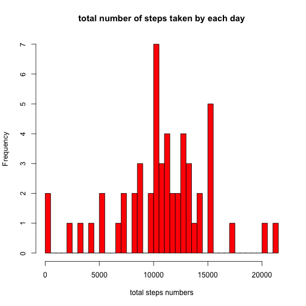

```r
hist(sumstep[,2],col="red",xlab="total steps numbers",main="total number of steps taken by each day",breaks=61)
```

3.calcualte the mean and median of the total number of steps taken per day

```r
meanstep<-sum(sumstep$x)/53
meanstep
```

```
## [1] 10766.19
```

```r
medianstep<-median(sumstep$x)
medianstep
```

```
## [1] 10765
```

## What is the average daily activity pattern?

1.make time series plot

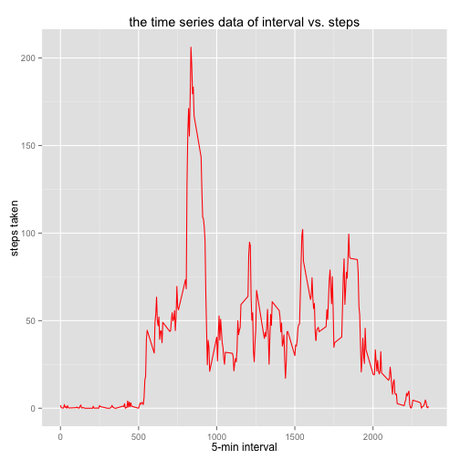

```r
intervalstep<-aggregate(newdata[,1],list(newdata$interval),mean)
timeseriesdata<-ggplot(intervalstep,aes(intervalstep[,1],intervalstep[,2]))+
  geom_line(color='red')+
  labs(title="the time series data of interval vs. steps")+
  xlab("5-min interval")+ylab("steps taken")
timeseriesdata
```

2.calculate which 5-minute interval has the maximum number of steps

```r
df3<-data.frame(x=intervalstep[,2])
m<-max(df3$x)
which(df3$x==m)
```

```
## [1] 104
```

####Therefore the 104th interval has the largest imputing missing values

1.total number of missing values in the dataset

```r
df4<-data.frame(project[,1],project[,2],project[,3])
sum(is.na(df4[,1]))
```

```
## [1] 2304
```

####Therefore, there are 2304 rows of missing values 2.devise the filling strategy for missing values

1. Create a new dataset that is equal to the original dataset

```r
missing<-is.na(df4[,1])
na<-split(project[,1][missing],project[,2])
```

####found only 8 dates have NA values and all the values are NAs

```r
s<-split(project$steps,project$date)
#replace NA values with 0
s[1]<-list(rep(0,288))
s[8]<-list(rep(0,288))
s[32]<-list(rep(0,288))
s[35]<-list(rep(0,288))
s[40]<-list(rep(0,288))
s[41]<-list(rep(0,288))
s[45]<-list(rep(0,288))
s[61]<-list(rep(0,288))

newdf<-do.call(rbind, lapply(s,data.frame,stringsAsFactors=FALSE))
newdf$date<-project$date
newdf$interval<-project$interval
```

1. make a histogram of the total number of steps taken each day

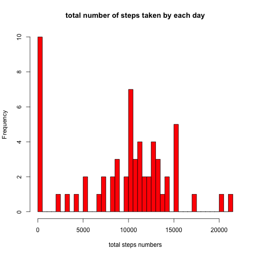

```r
sumstep1<-aggregate(newdf[,1],list(newdf$date),sum)

newhist<-hist(sumstep1[,2],col="red",xlab="total steps numbers",main="total number of steps taken by each day",breaks=61)
```

5. Calculate and report the mean and median

```r
meanstep1<-sum(sumstep1[,2])/53
meanstep1
```

```
## [1] 10766.19
```

```r
medianstep1<-median(sumstep1[,2])
medianstep1
```

```
## [1] 10395
```

## Are there differences in activity patterns between weekdays and weekends?

Yes. There are differences.

1.transform factor into date format

```r
time<-as.Date(newdf[,2],format="%Y-%m-%d")
```

2.translate date into weekdays and add into newdf

```r
newdf$weekday<-weekdays(time)

newdf$weekday[newdf$weekday=="Sunday"| newdf$weekday=="Saturday"]<-"Weekend"
newdf$weekday[newdf$weekday=="Monday"| newdf$weekday=="Tuesday"| newdf$weekday=="Wednesday"| newdf$weekday=="Thursday"| newdf$weekday=="Friday"]<-"Weekdays"
newdf$weekday<-newdf$weekday
```

3.make the time series plot

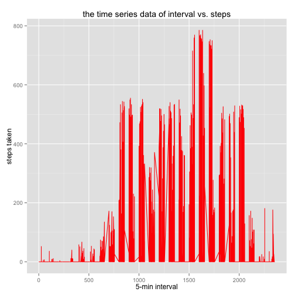

```r
ninterval<-as.numeric(newdf$interval)
df1<-newdf[which(newdf$weekday=="Weekend"),]
df2<-newdf[which(newdf$weekday=="Weekdays"),]
timeseriesdata1<-ggplot(df1,aes(df1[,3],df1[,1]))+
  geom_line(color='red')+
  labs(title="the time series data of interval vs. steps")+
  xlab("5-min interval")+ylab("steps taken")

timeseriesdata2<-ggplot(df2,aes(df2[,3],df2[,1]))+
  geom_line(color='red')+
  labs(title="the time series data of interval vs. steps")+
  xlab("5-min interval")+ylab("steps taken")
timeseriesdata1
```

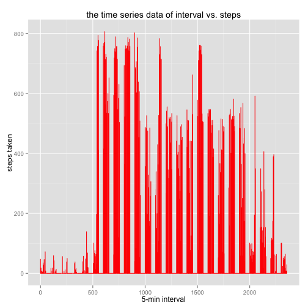

```r
timeseriesdata2
```